# Homework 8

Christopher Bussen

2023-04-19

```r
library(tidyverse)
```

1. Read the data file, adult.data using the read_csv() function in tidyverse. This data don’t have column names included. You must indicate the column names when reading the data (in the same order I listed above).

```r
adult <- read_csv("adult.data", col_names = c("age", "workclass", "fnlwgt", "education", "education_num", "martial_status", "occupation", "relationship", "race", "sex", "captial_gain", "captial_loss", "hours_per_week", "native_country", "income_level"))
```

2. Subset the data to use only the income information from people in the United States. You should use this subset data for the rest of the questions.

```r
adult <- filter(adult, adult$native_country == "United-States")
```

3. Get a glimpse of the data. Study the distribution of income_level. 50K is 50000 US dollars. Note: You should notice that there were more people whose income was less than 50K. When we study the factors that may impact the income level, we need to consider this and consider how to have “fair” comparisons.

```r
glimpse(adult)
```

```
## Rows: 29,170
## Columns: 15
## $ age            <dbl> 39, 50, 38, 53, 37, 52, 31, 42, 37, 23, 32, 25, 32, 38,…
## $ workclass      <chr> "State-gov", "Self-emp-not-inc", "Private", "Private", …
## $ fnlwgt         <dbl> 77516, 83311, 215646, 234721, 284582, 209642, 45781, 15…
## $ education      <chr> "Bachelors", "Bachelors", "HS-grad", "11th", "Masters",…
## $ education_num  <dbl> 13, 13, 9, 7, 14, 9, 14, 13, 10, 13, 12, 9, 9, 7, 14, 1…
## $ martial_status <chr> "Never-married", "Married-civ-spouse", "Divorced", "Mar…
## $ occupation     <chr> "Adm-clerical", "Exec-managerial", "Handlers-cleaners",…
## $ relationship   <chr> "Not-in-family", "Husband", "Not-in-family", "Husband",…
## $ race           <chr> "White", "White", "White", "Black", "White", "White", "…
## $ sex            <chr> "Male", "Male", "Male", "Male", "Female", "Male", "Fema…
## $ captial_gain   <dbl> 2174, 0, 0, 0, 0, 0, 14084, 5178, 0, 0, 0, 0, 0, 0, 0, …
## $ captial_loss   <dbl> 0, 0, 0, 0, 0, 0, 0, 0, 0, 0, 0, 0, 0, 0, 0, 0, 0, 0, 2…
## $ hours_per_week <dbl> 40, 13, 40, 40, 40, 45, 50, 40, 80, 30, 50, 35, 40, 50,…
## $ native_country <chr> "United-States", "United-States", "United-States", "Uni…
## $ income_level   <chr> "<=50K", "<=50K", "<=50K", "<=50K", "<=50K", ">50K", ">…
```

```r
table(adult$income_level)
```

```
##
## <=50K  >50K
## 21999  7171
```

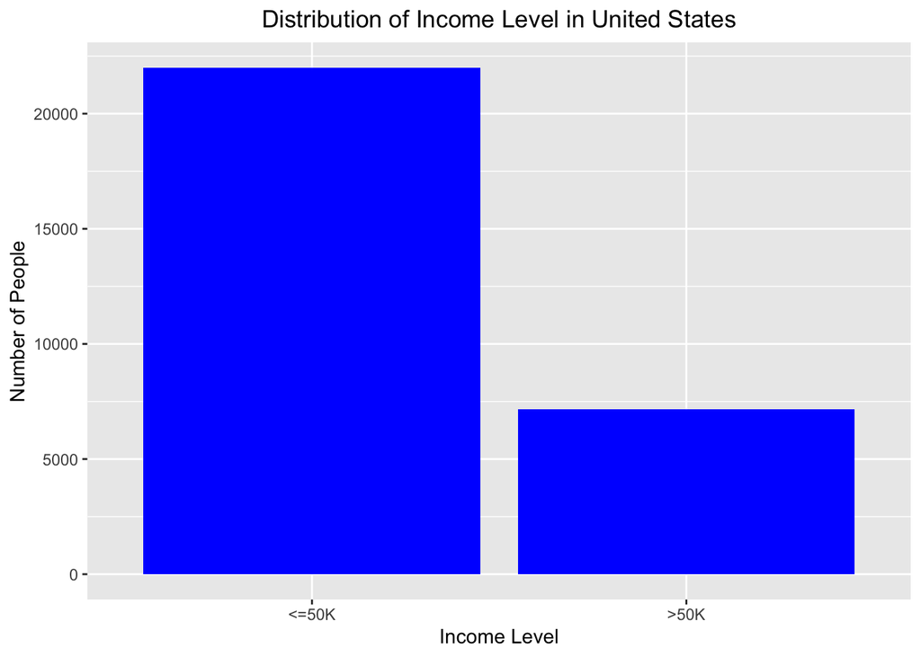

```r
ggplot(adult, aes(x=income_level)) +
  geom_bar(fill="blue") +
  labs(title = "Distribution of Income Level in United States", x = "Income Level", y = "Number of People") +
  theme(plot.title = element_text(hjust = 0.5))
```

As we can see from both the table and the bar graph above, there are far more people in the dataset who have an income of less than or equal to $50,000 compared to the number of people with an income greater than $50,000. In fact, there are almost three times as many people in this dataset who make less than or equal to $50,000 when compared to those in the dataset who make more than $50,000.

4. Create a new variable age_group using age by the following categories:

20-, 20-30, 30-40, 40-50, 50-60, 60-70, 70-80, 80+

20-: the age is less than 20 and 80+: the age is greater than or equal to 80

20-30: 20 <= age < 30, 30-40: 30 <= age < 40, etc.

```r
adult <- adult %>%
  mutate(age_group = cut(age, breaks = c(0, 20, 30, 40, 50, 60, 70, 80, Inf),
                         right = FALSE,
                         labels = c("20-", "20-30", "30-40", "40-50", "50-60", "60-70", "70-80", "20-")))
table(adult$age_group)
```

```
##
##   20- 20-30 30-40 40-50 50-60 60-70 70-80
##  1664  7111  7651  6442  3983  1850   469
```

5. Use these three variables: age_group, hours_per_week, and income_level, to study the impact of the first two variables on the income level. You should include your analysis.

```r
table(adult$income_level, adult$age_group)
```

```
##
##          20- 20-30 30-40 40-50 50-60 60-70 70-80
##   <=50K 1648  6649  5562  3990  2410  1361   379
##   >50K    16   462  2089  2452  1573   489    90
```

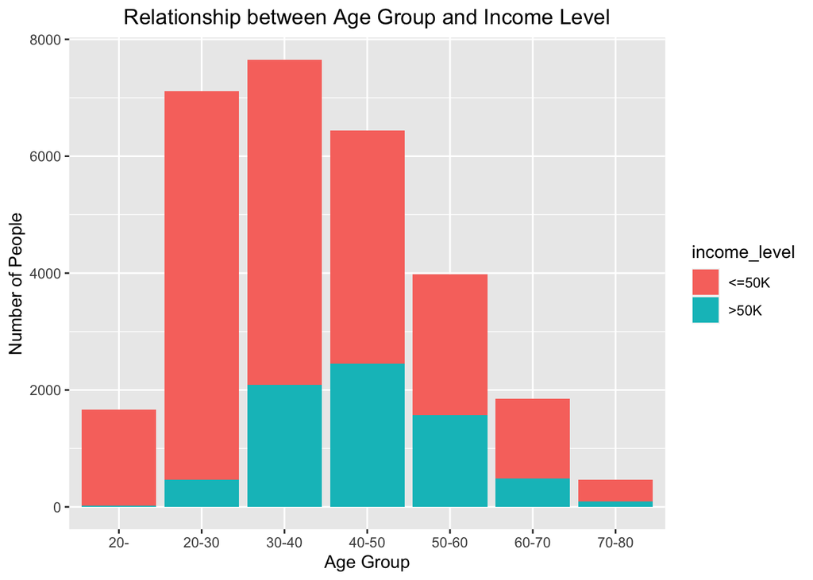

```r
ggplot(adult, aes(x = age_group, fill = income_level)) +
  geom_bar() +
  labs(title = "Relationship between Age Group and Income Level", x = "Age Group", y = "Number of People") +
  theme(plot.title = element_text(hjust = 0.5))
```

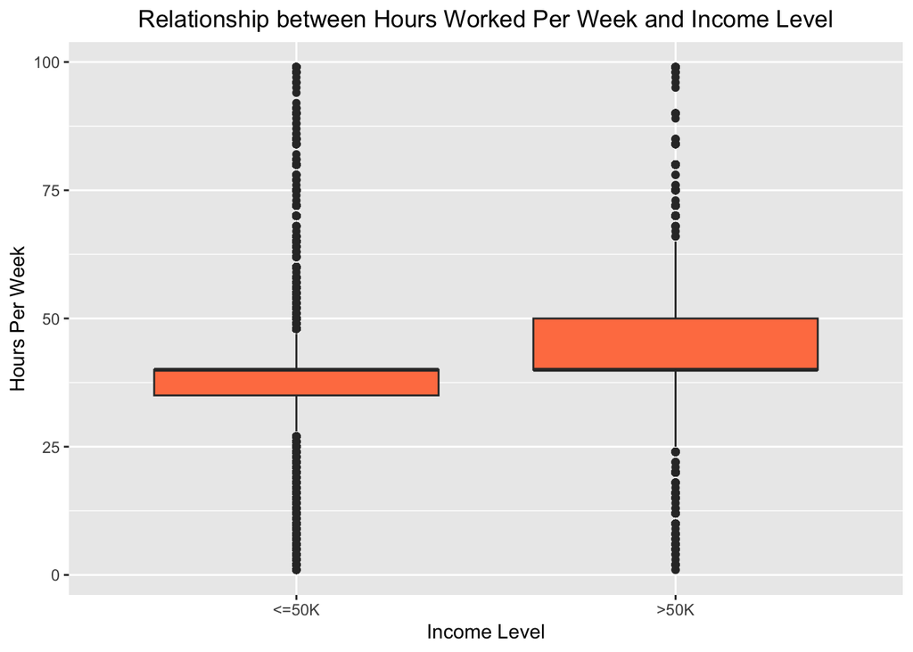

```r
ggplot(adult, aes(x = income_level, y = hours_per_week)) +
  geom_boxplot(fill = "coral") +
  labs(title = "Relationship between Hours Worked Per Week and Income Level", x = "Income Level", y = "Hours Per Week") +
  theme(plot.title = element_text(hjust = 0.5))
```

```r
median(filter(adult, adult$income_level == "<=50K")$hours_per_week)
```

```
## [1] 40
```

```r
median(filter(adult, adult$income_level == ">50K")$hours_per_week)
```

```
## [1] 40
```

To study the relationship between hours per week and income level, I decided to create boxplots of hours per week for each of the two income levels. From these boxplots, we can see that both income levels have the same median of hours per week, at 40 hours. This makes sense because regardless of pay, full-time jobs are normally considered to be 40 hour weeks. However, we can see that the middle 50% of hours per week is higher for people who make more than $50,000 than it is for people who make less than or equal to $50,000. Additionally, we can see that the IQR and spread from Q1-1.5IQR to Q3+1.5IQR are both also greater for people who make over $50,000. One thing worth noting that this tells us is it is more common for people who make more than $50,000 to vary in their hours per week without being outliers (both on the low and high ends) whereas the income level of less than or equal to $50,000 sees much less variation in hours worked per week. Finally, we can see that there tend to be more outliers, both high and low, in hours worked per week for people who make less than or equal to $50,000.

6. The document provided no information about the variable: education_num. Can you use another variable (s) in the data to determine the meaning of these values? Indicate the education level for each number in this variable.

```r
nlevels(as.factor(adult$education))
```

```
## [1] 16
```

```r
nlevels(as.factor(adult$education_num))
```

```
## [1] 16
```

```r
# filter(adult, education_num==16)$education -- switched education_num and used this line to figure out what each number represents
```

Yes, we can use the variable education to determine the meaning of the variable education_num. As we can see from using the nlevels function above and changing the education variable to a factor, it has 16 unique values. The same can be said of education_num, which contains numbers 1-16. So, we can see that education_num is just a numeric way of representing the education variable. For this variable, 1 represents “Preschool”, 2 is “1st-4th”, 3 is “5th-6th”, 4 is “7th-8th”, 5 is “9th”, 6 is “10th”, 7 is “11th”, 8 is “12th”, 9 is “HS-grad”, 10 is “Some-college”, 11 is “Assoc-voc”, 12 is “Assoc-acdm”, 13 is “Bachelors”, 14 is “Masters”, 15 is “Prof-school”, and 16 is “Doctorate”.

7. Now, you should find that there are many categories in the variable: education and some categories have fewer counts. Decide how you could regroup these categories by yourself and use the variable education after you regroup categories to study its impact on the income level. You should explain your approach, i.e., why certain categories should be grouped.

```r
table(adult$education)
```

```
##
##         10th         11th         12th      1st-4th      5th-6th      7th-8th
##          848         1067          365           46           97          499
##          9th   Assoc-acdm    Assoc-voc    Bachelors    Doctorate      HS-grad
##          395          982         1289         4766          328         9702
##      Masters    Preschool  Prof-school Some-college
##         1527           17          502         6740
```

```r
regroup_adult_ed <- adult %>%
  mutate(education = recode(education,
                            "9th"= "Some-HS", "10th"= "Some-HS", "11th"= "Some-HS", "12th" = "Some-HS",
                            "Assoc-acdm" = "Associates", "Assoc-voc" = "Associates",
                            "Preschool" = "Pre-HS", "1st-4th" = "Pre-HS", "5th-6th" = "Pre-HS", "7th-8th" = "Pre-HS",
                            "Masters" = "Post-grad", "Doctorate" = "Post-grad", "Prof-school" = "Post-grad"
  ))

table(regroup_adult_ed$education)
```

```
##
##   Associates    Bachelors      HS-grad    Post-grad       Pre-HS Some-college
##         2271         4766         9702         2357          659         6740
##      Some-HS
##         2675
```

For this question, I decided to start with grouping together everything before high school (preschool through 8th grade) and calling it pre HS. This is because none of them had a large amount of people and I felt like high school was the first major milestone in terms of education received. From there, I decided to group together anything that was highschool education prior to graduating high school (9th-12th), AKA high school dropouts. I did this because I did not think there was much of a difference between someone dropping out in their freshman year versus their senior year. I then left HS grad and some college alone because they both had a good amount of people and I felt like they were good benchmarks in terms of education levels. After this, I decided to combine both types of associates degrees because I thought that it made the groups more consistent and easier to understand. I kept bachelors the same because it is one of the more popular educational routes. Finally, I grouped together masters, doctorate, and prof school because they are all just different types of post-grad schooling and none of them were particularly common on their own.

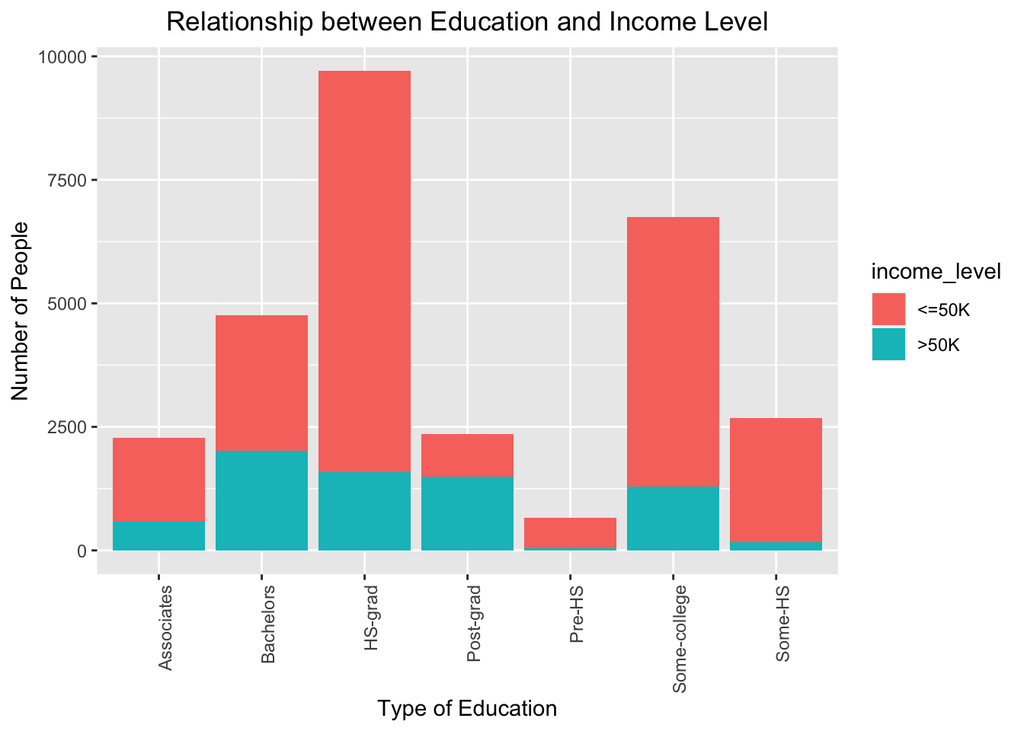

```r
ggplot(regroup_adult_ed, aes(x = education, fill = income_level)) +
  geom_bar() +
  labs(title = "Relationship between Education and Income Level", x = "Type of Education", y = "Number of People") +
  theme(plot.title = element_text(hjust = 0.5), axis.text.x = element_text(angle = 90, hjust = 1))
```

As the stacked bar chart shows us, for the lesser education groups such as pre-HS, some-HS and HS-grad, a very low proportion of people make more than $50,000. This is not particularly surprising as they are not as educated as others. Both associates and some-college have slightly higher proportions of people in the higher income level, yet they are still not particularly high. However, when you get to bachelors and post-grad, you notice that a much higher proportion of people make more than $50,000 - close to half for bachelors and well over half for post-grad. Thus, we can see overall that a higher level of education gives a better chance at higher income.

8. Based on the data, give at least one reason why it is not worth analyzing the relationship between captial_gain and income level and captial_loss and income level.

```r
table(adult$captial_gain)
```

```
##
##     0   114   401   594   914   991  1055  1086  1111  1151  1173  1409  1424
## 26699     6     2    31     7     5    24     4     1     7     2     6     3
##  1455  1471  1506  1639  1797  1831  1848  2009  2036  2050  2062  2105  2174
##     1     6    13     1     7     6     5     3     4     5     1     7    41
##  2176  2202  2228  2290  2329  2346  2354  2387  2407  2414  2463  2538  2580
##    21    13     5     3     6     4    10     1    18     8     8     1    11
##  2597  2635  2653  2829  2885  2907  2936  2961  2964  2977  2993  3103  3137
##    19    10     5    26    21     9     2     3     8     7     2    92    29
##  3273  3325  3411  3418  3432  3456  3464  3471  3674  3781  3818  3887  3908
##     6    51    18     5     4     2    19     7    13     9     7     5    32
##  3942  4064  4101  4386  4416  4508  4650  4687  4787  4865  4931  4934  5013
##    11    37    19    65    11     7    40     3    21    17     1     7    63
##  5060  5178  5455  5556  5721  6097  6360  6418  6497  6514  6723  6767  6849
##     1    88    11     4     3     1     3     9    11     5     2     5    26
##  7298  7430  7443  7688  7896  7978  8614  9386  9562 10520 10566 10605 11678
##   228     6     5   261     2     1    50    19     4    42     6    12     2
## 13550 14084 14344 15020 15024 15831 18481 20051 22040 25124 25236 27828 34095
##    25    39    24     4   320     4     2    32     1     4    11    30     5
## 41310 99999
##     1   142
```

```r
table(adult$captial_loss)
```

```
##
##     0   155   213   323   419   625   653   810   880   974  1092  1138  1258
## 27791     1     3     3     2    11     3     2     6     2     5     2     4
##  1340  1380  1408  1411  1485  1504  1539  1564  1573  1579  1590  1594  1602
##     7     6    19     1    45    18     1    20     5    16    35     7    42
##  1617  1628  1648  1651  1668  1669  1672  1719  1721  1726  1735  1740  1741
##     9    13     1     6     2    23    33    20    18     4     2    40    23
##  1755  1762  1816  1825  1844  1848  1876  1887  1902  1944  1974  1977  1980
##     2    12     2     4     1    48    36   147   183     1    18   153    21
##  2001  2002  2042  2051  2057  2129  2149  2174  2179  2205  2206  2231  2238
##    24    19     9    20     4     2     2     7    12     8     5     3     2
##  2246  2258  2267  2282  2339  2352  2377  2392  2415  2444  2457  2467  2472
##     6    23     3     1    13     2    19     9    41    12     2     1     1
##  2489  2547  2559  2603  2754  2824  3004  3683  3770  3900  4356
##     1     4    12     3     2     9     1     2     2     2     3
```

The main reason why it is not worth analyzing the relationship between capital gain/capital loss and income is because a vast majority of the observations are 0 for both variables (tables above show around 27,000 of 29,170 for each variable being 0). This would result in the distribution being heavily skewed and the data focused primarily on the low end. As a result, it would likely be very difficult to draw legitimate conclusions or make accurate predictions based on the data.

9. Pick at least 2 variables from occupation, relationship, race, and sex to study their impact on the income level. You should talk about what you find based on your analysis.

I will look at the impacts of relationship and race on income level in this problem. I’m quite interested to look at how relationship relates to income level because many people today tend to always think of men/husbands as the breadwinners. However, I think this has started to shift at least slightly over the last few decades as women have become more accepted in the workforce and different higher-paying fields. I am also curious to look at race just because it plays a huge role in many aspects of life in the United States and many groups are consistently discriminated against. I’m curious to see if this discrimination is noticeable through income level as well.

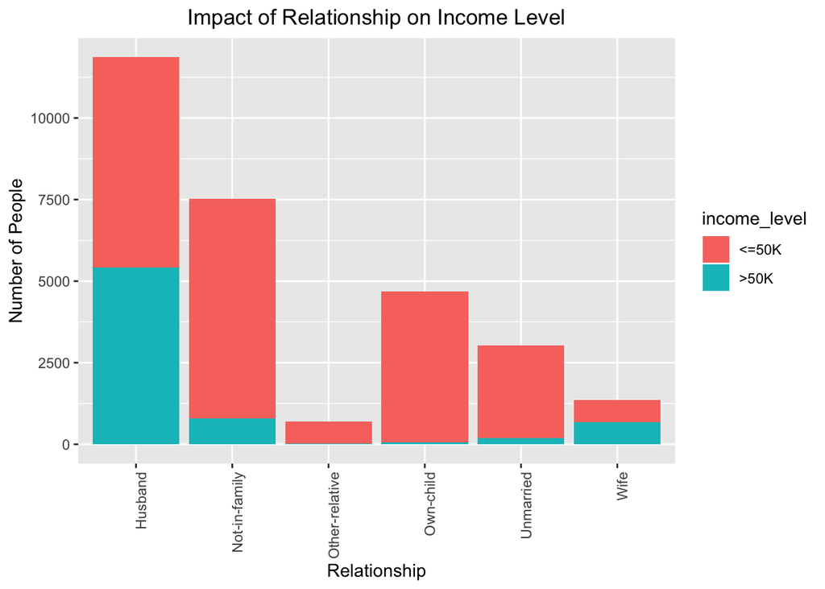

```r
ggplot(regroup_adult_ed, aes(x = relationship, fill = income_level)) +
  geom_bar() +
  labs(title = "Impact of Relationship on Income Level", x = "Relationship", y = "Number of People") +
  theme(plot.title = element_text(hjust = 0.5), axis.text.x = element_text(angle = 90, hjust = 1))
```

As we can see from the bar chart above, husband is by far the most common relationship in the dataset, and slightly under half of them make more than $50,000. While wife is the second least common relationship type in the dataset (meaning that many wives do not work), it is interesting to see that half of them make over $50,000. Other than these two relationships, the rest are overwhelmingly in the lower income level, especially own-child.

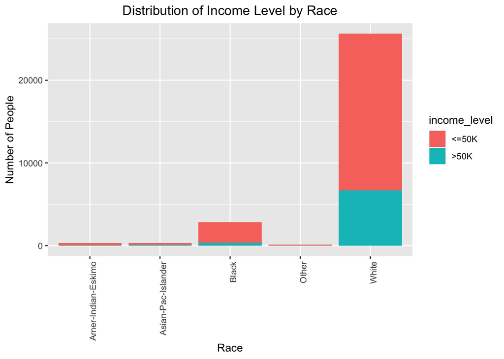

```r
ggplot(adult, aes(x = race, fill = income_level)) +
  geom_bar() +
  labs(title = "Distribution of Income Level by Race", x = "Race", y = "Number of People") +
  theme(plot.title = element_text(hjust = 0.5), axis.text.x = element_text(angle = 90, hjust = 1))
```

From this stacked bar chart, we can first see that the vast majority of this dataset is made up of people who are classified as either black or white. White people have by far the highest proportion of people who make more than $50,000, which I think most people would expect in America (proportion appears to be around 1/4). After them, black people have the next highest proportion of people with an income over $50,000. Aside from white and black people, the rest of the listed races are made up almost only of people making less than or equal to $50,000.

10. Name at least one thing I didn’t mention above but studying could be good. (Not necessarily related to income level)

One thing not mentioned above that could be worth studying is the relationship between sex and income level based on occupation (similar to above but more specific). This is because the wage gap is something that is a very popular and rather controversial point of debate in our society today, yet it is important to recognize that their could be other factors affecting the person’s income other than just gender. Obviously, men and women are not always doing the same jobs and as a result will make different amounts of money. One way that we could reduce the impact of this variable when analyzing the relationship between gender and income level is to either group by occupations and calculate the average income for each gender (can’t do with current dataset but would be interesting) or just filter by some of the more popular occupations and look at the distribution of income level by gender. I will provide an example below.

```r
table(adult$occupation)
```

```
##
##                 ?      Adm-clerical      Armed-Forces      Craft-repair
##              1666              3449                 9              3685
##   Exec-managerial   Farming-fishing Handlers-cleaners Machine-op-inspct
##              3735               879              1189              1687
##     Other-service   Priv-house-serv    Prof-specialty   Protective-serv
##              2777                90              3693               606
##             Sales      Tech-support  Transport-moving
##              3364               850              1491
```

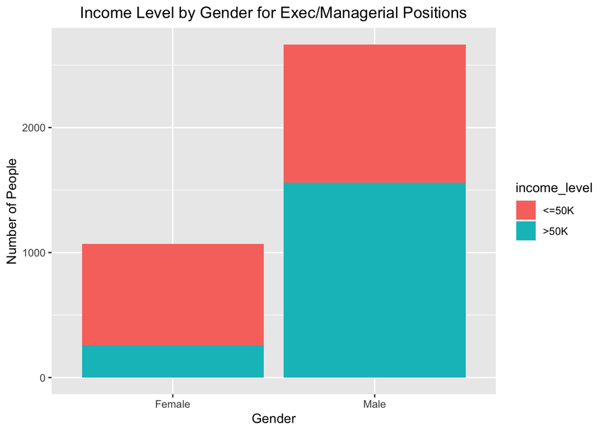

```r
# exec-managerial is most common so will look at that

ggplot(filter(adult, adult$occupation == "Exec-managerial"), aes(x = sex, fill = income_level)) +
  geom_bar() +
  labs(title = "Income Level by Gender for Exec/Managerial Positions", x = "Gender", y = "Number of People") +
  theme(plot.title = element_text(hjust = 0.5))
```

As we can see here, this stacked bar chart shows us that for the same type of occupation, far less females are in the higher income level compared to males (females closer to 1/4, males closer to 1/2). Additionally, it shows us that there are over double the amount of males in these professions compared to women. This could be very interesting and valuable information if analyzed for several occupations.

Finally, I think marital status would be interesting to look at in relation to income. This is because marital status can often affect a person’s ability to work. Additionally, if someone is married they might want to make more money in order to potentially be able to support a family in the future. I think it would also be interesting to look at the distribution of income level for widows, as many of them likely were not working prior to the death of their spouse and now are in need of a new source of income. As a result, I would be curious to see if there is any noticeable relationship between marital status and income level.

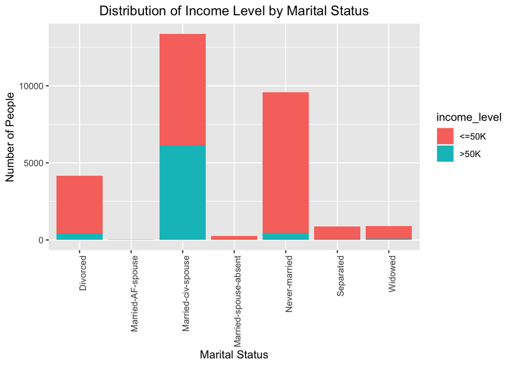

```r
ggplot(adult, aes(x = martial_status, fill = income_level)) +
  geom_bar() +
  labs(title = "Distribution of Income Level by Marital Status", x = "Marital Status", y = "Number of People") +
  theme(plot.title = element_text(hjust = 0.5), axis.text.x = element_text(angle = 90, hjust = 1))
```

As we can see from the figure above, the most common marital statuses are married-civ-spouse, never-maried, and divorced. Married-civ-spouse by far has the highest proportion of people making more than $50,000, at a little under half. For every other marital status, the overwhelming majority of people make less than or equal to $50,000. The same is true for widows (which I briefly mentioned above), and I believe this is likely because many of them have not been in the workforce for a long time. As a result, it can be rather difficult for them to get higher paying jobs which puts them in the lower income level.